# Next Word PredictR

Benedict Neo  
16th November, 2021

Data Science Specialization Capstone Project  
Johns Hopkins University

# **About**

Below you can find links to the app and to the source code

- [source code on Github](https://github.com/benthecoder/next-word-predictor/)

- [Shiny App](https://benthecoder.shinyapps.io/Next-Word-PredictR/)

# **Markov Chains**

Markov chains are a way to model events with discrete states with defined probabilities of moving between states.

Take the weather for example, if it rained yesterday, we have a discrete state with defined probability of raining yesterday, and raining today.

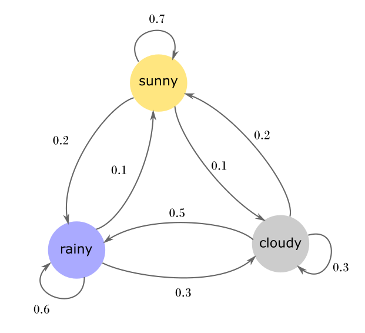

# **Markov chain for next word prediction**

The predictive text model was built from a sample of 200k lines extracted from a random sample of a large corpus of blogs, news and twitter data (over 4 million lines).

The sample data was tokenized and cleaned with tidytext. Cleaning process included removing profane words, all non-ascii characters, and all words were lowercased. The strings were then split into tokens (n-grams).

The markov model was built using the `markovchain` package, and it utilizes only the unigrams due to resource limitations of the shiny app.

# **The Shiny App**

A picture of the shiny app is below.

Users will enter a text on a textbox on the left side and the predicted words are on the right side in a box. Users can also select the number of words they want to predict by inputting in the amount of words below the textbox.

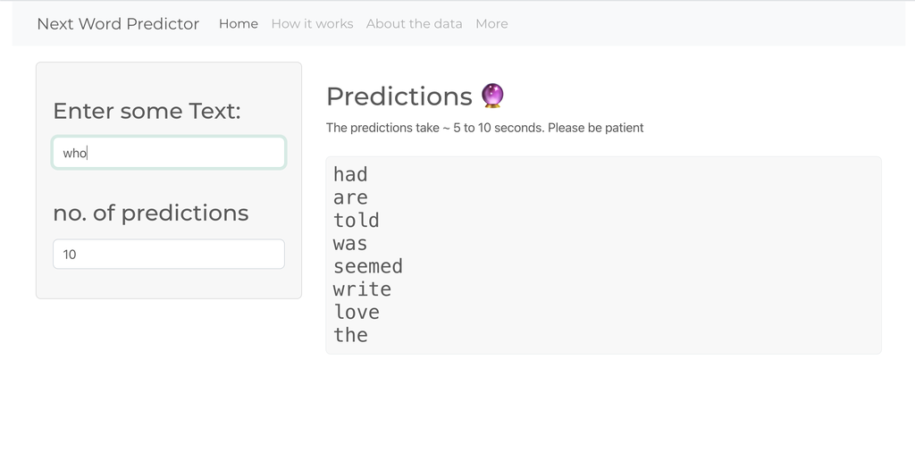